# InVivoStat Linear Discriminant Analysis

## Description

The purpose of linear discriminant analysis (LDA) is to identify the linear combinations of the original variables that gives the best possible separation between the groups.

The following responses are included in the analysis: Sepal length,Sepal width,Petal width,Petal length.

## Group means

| Categorical Binary 2 levels | Sepal length | Sepal width | Petal width | Petal length |
| --- | --- | --- | --- | --- |
| A | 5.8 | 3.1 | 1.2 | 3.8 |
| B | 5.8 | 3.1 | 1.2 | 3.7 |

This table contains the means for each response, categorised by the categorical predictor.

## Coefficients of the linear discriminant functions (LD)

| Response | LD1 |
| --- | --- |
| Sepal length | 1.38 |
| Sepal width | -1.28 |
| Petal width | -3.35 |
| Petal length | 0.61 |

This table contains the coefficients that are used to calculate the linear combinations of the original variables (the linear discriminant functions).

## Values of the linear discriminant function

| Case ID | Sepal length | Sepal width | Petal width | Petal length | Categorical factor | LD1 |
| --- | --- | --- | --- | --- | --- | --- |
| 1 | 5.1 | 3.5 | 0.2 | 1.4 | A | 0.3238 |
| 2 | 4.9 | 3.0 | 0.2 | 1.4 | B | 0.6888 |
| 3 | 4.7 | 3.2 | 0.2 | 1.3 | A | 0.0949 |
| 4 | 4.6 | 3.1 | 0.2 | 1.5 | B | 0.2060 |
| 5 | 5.0 | 3.6 | 0.3 | 1.4 | A | -0.2777 |
| 6 | 5.4 | 3.9 | 0.4 | 1.7 | B | -0.2626 |
| 7 | 4.6 | 3.4 | 0.3 | 1.4 | A | -0.5744 |
| 8 | 5.0 | 3.4 | 0.2 | 1.5 | B | 0.3743 |
| 9 | 4.4 | 2.9 | 0.2 | 1.4 | A | 0.1255 |
| 10 | 4.9 | 3.1 | 0.1 | 1.5 | B | 0.9559 |
| 11 | 5.4 | 3.7 | 0.2 | 1.5 | A | 0.5426 |
| 12 | 4.8 | 3.4 | 0.2 | 1.6 | B | 0.1583 |
| 13 | 4.8 | 3.0 | 0.1 | 1.4 | A | 0.8853 |
| 14 | 4.3 | 3.0 | 0.1 | 1.1 | B | 0.0120 |
| 15 | 5.8 | 4.0 | 0.2 | 1.2 | A | 0.5292 |
| 16 | 5.7 | 4.4 | 0.4 | 1.5 | B | -0.6104 |
| 17 | 5.4 | 3.9 | 0.4 | 1.3 | A | -0.5049 |
| 18 | 5.1 | 3.5 | 0.3 | 1.4 | B | -0.0111 |
| 19 | 5.7 | 3.8 | 0.3 | 1.7 | A | 0.6156 |
| 20 | 5.1 | 3.8 | 0.3 | 1.5 | B | -0.3355 |
| 21 | 5.4 | 3.4 | 0.2 | 1.7 | A | 1.0488 |
| 22 | 5.1 | 3.7 | 0.4 | 1.5 | B | -0.5420 |
| 23 | 4.6 | 3.6 | 0.2 | 1.0 | A | -0.7385 |
| 24 | 5.1 | 3.3 | 0.5 | 1.7 | B | -0.2424 |
| 25 | 4.8 | 3.4 | 0.2 | 1.9 | A | 0.3400 |
| 26 | 5.0 | 3.0 | 0.2 | 1.6 | B | 0.9483 |
| 27 | 5.0 | 3.4 | 0.4 | 1.6 | A | -0.2348 |
| 28 | 5.2 | 3.5 | 0.2 | 1.5 | B | 0.5227 |
| 29 | 5.2 | 3.4 | 0.2 | 1.4 | A | 0.5904 |
| 30 | 4.7 | 3.2 | 0.2 | 1.6 | B | 0.2766 |

[output cut: 120 more lines]

This table contains the linear discriminant functions along with the original responses.

## Histogram of the first linear discriminant function values, categorised by Categorical Binary 2

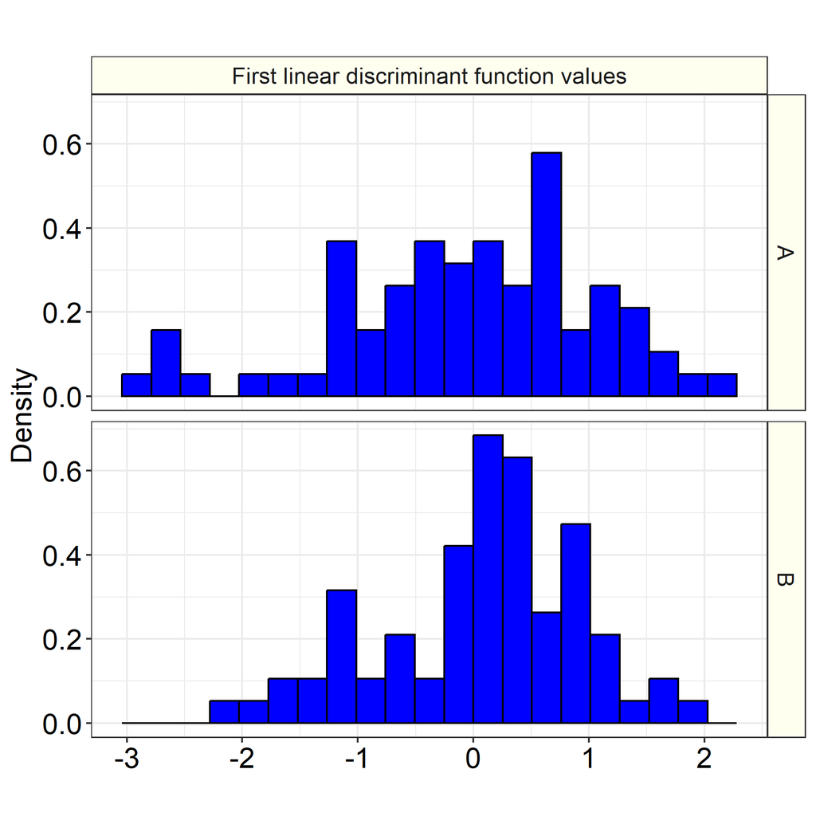

## Confusion matrix of classifications

| Categorical Binary 2 levels | A | B |
| --- | --- | --- |
| A | 36 | 28 |
| B | 39 | 47 |

This table summarises the classification of the individual cases, based on the linear discriminant function values.

## Table of mis-classified cases

| Case ID | Predicted group | Actual group |
| --- | --- | --- |
| 1 | B | A |
| 3 | B | A |
| 6 | A | B |
| 9 | B | A |
| 11 | B | A |
| 13 | B | A |
| 15 | B | A |
| 16 | A | B |
| 18 | A | B |
| 19 | B | A |
| 20 | A | B |
| 21 | B | A |
| 22 | A | B |
| 24 | A | B |
| 25 | B | A |
| 29 | B | A |
| 31 | B | A |
| 33 | B | A |
| 34 | A | B |
| 35 | B | A |
| 37 | B | A |
| 44 | A | B |
| 47 | B | A |
| 49 | B | A |
| 51 | B | A |
| 53 | B | A |
| 55 | B | A |
| 58 | A | B |
| 59 | B | A |
| 60 | A | B |
| 61 | B | A |
| 62 | A | B |
| 63 | B | A |
| 69 | B | A |
| 73 | B | A |
| 75 | B | A |
| 77 | B | A |
| 81 | B | A |
| 83 | B | A |
| 86 | A | B |
| 87 | B | A |
| 91 | B | A |
| 93 | B | A |
| 95 | B | A |
| 102 | A | B |
| 103 | B | A |
| 104 | A | B |
| 109 | B | A |
| 110 | A | B |
| 112 | A | B |
| 114 | A | B |
| 116 | A | B |
| 117 | B | A |
| 119 | B | A |
| 122 | A | B |
| 123 | B | A |
| 124 | A | B |
| 128 | A | B |
| 131 | B | A |
| 135 | B | A |
| 138 | A | B |
| 140 | A | B |
| 142 | A | B |
| 144 | A | B |
| 146 | A | B |
| 148 | A | B |
| 150 | A | B |

This table summarises the cases that are mis-classified, based on the linear discriminant function values.

## Table of correctly classified cases

| Case ID | Predicted group | Actual group |
| --- | --- | --- |
| 2 | B | B |
| 4 | B | B |
| 5 | A | A |
| 7 | A | A |
| 8 | B | B |
| 10 | B | B |
| 12 | B | B |
| 14 | B | B |
| 17 | A | A |
| 23 | A | A |
| 26 | B | B |
| 27 | A | A |
| 28 | B | B |
| 30 | B | B |
| 32 | B | B |
| 36 | B | B |
| 38 | B | B |
| 39 | A | A |
| 40 | B | B |
| 41 | A | A |
| 42 | B | B |
| 43 | A | A |
| 45 | A | A |
| 46 | B | B |
| 48 | B | B |
| 50 | B | B |
| 52 | B | B |
| 54 | B | B |
| 56 | B | B |
| 57 | A | A |

[output cut: 53 more lines]

This table summarises the cases that are classified correctly, based on the linear discriminant function values.

## References

When referring to InVivoStat, please cite 'InVivoStat, version 5.2.0'.